# ggplot2の辞書

#### 2.2.7.1 因子にして順序を指定する場合

- ここでは同時に実行しているが、そもそものデータフレームで因子型で順序を指定し作成しておけばその順序が反映される

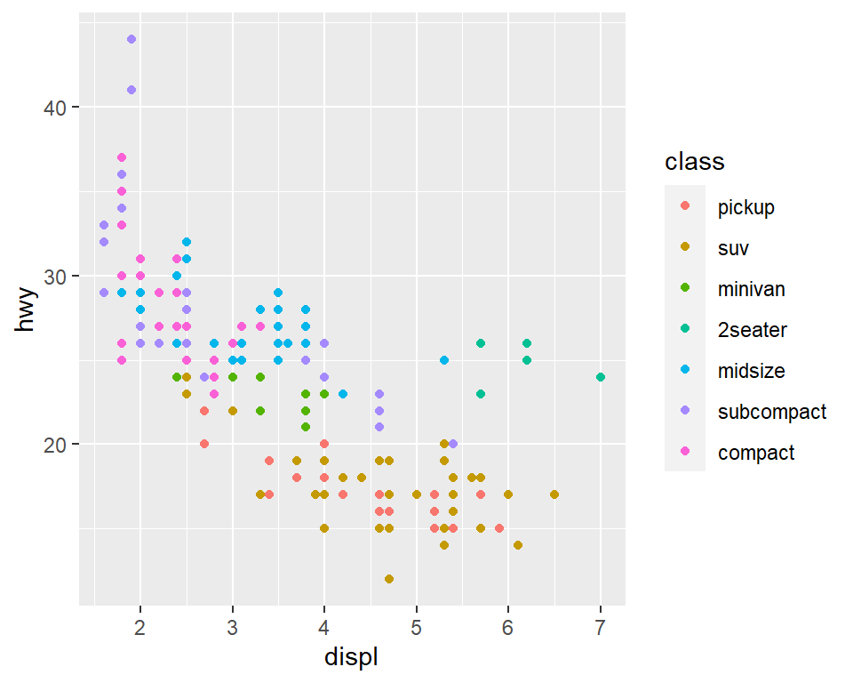

```r
mpg %>%
  mutate(class = fct_relevel(class,
                             "pickup", "suv", "minivan",
                          "2seater", "midsize", "subcompact", "compact")) %>%
ggplot(aes(displ, hwy,
                color = class)) +
  geom_point()
```

### 2.2.8 凡例の背景色を消す

- 詳しくは https://ggplot2.tidyverse.org/reference/theme.html

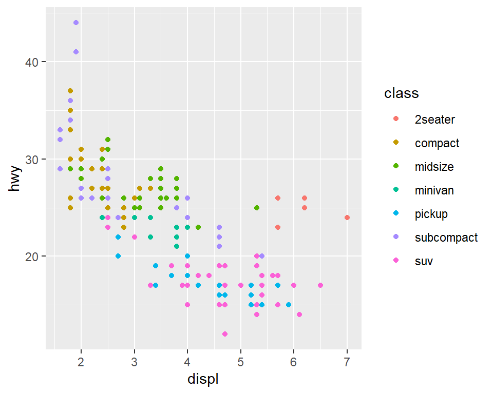

```r
pc +
 geom_point() +
  theme(legend.key = element_blank())
```

## 2.3 一部のデータを目立たせる

- `geom_point()`を重ね書き
  - 目立たせる車種を`filter()`で選択

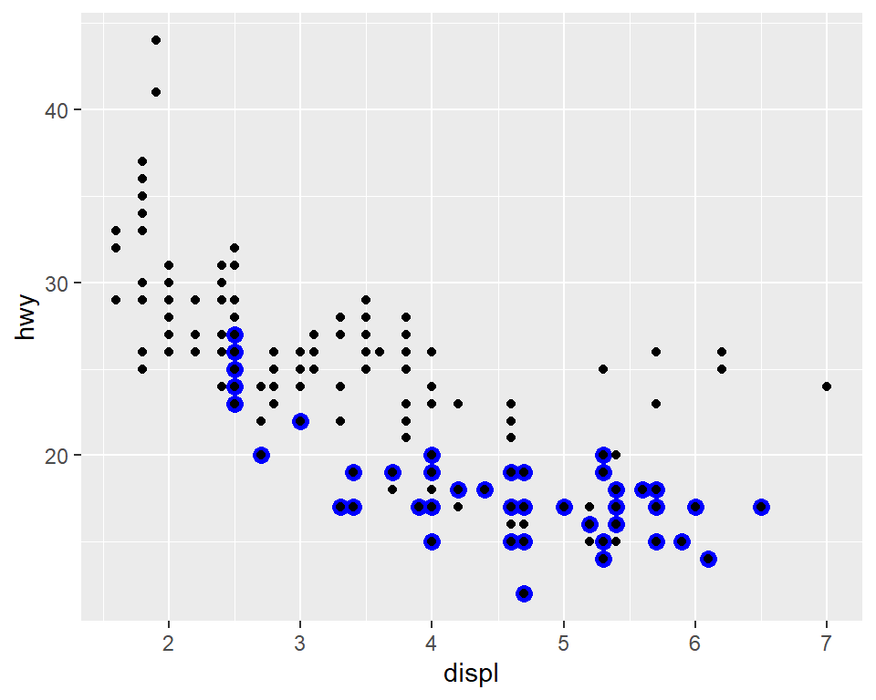

```r
pp <-
p +
# suvのデータのみプロット
   geom_point(
     data = filter(mpg, class == "suv"),
     color = "blue",
     size = 3) +
# 通常のプロット
   geom_point()

pp
```

### 2.3.1 ラベル付け

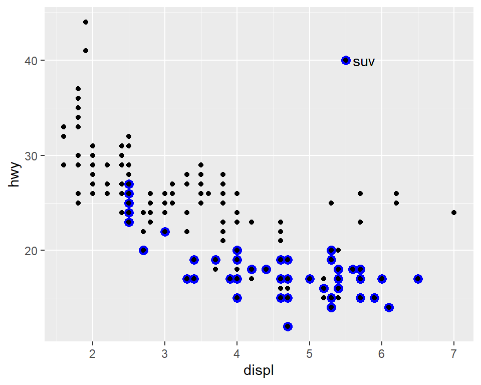

```r
pp +
annotate(geom = "point", x = 5.5, y = 40, colour = "blue", size = 3) +
annotate(geom = "point", x = 5.5, y = 40) +
annotate(geom = "text", x = 5.6, y = 40, label = "suv", hjust = "left")
```

## 2.4 変数の水準ごとにプロット: facet_wrap()

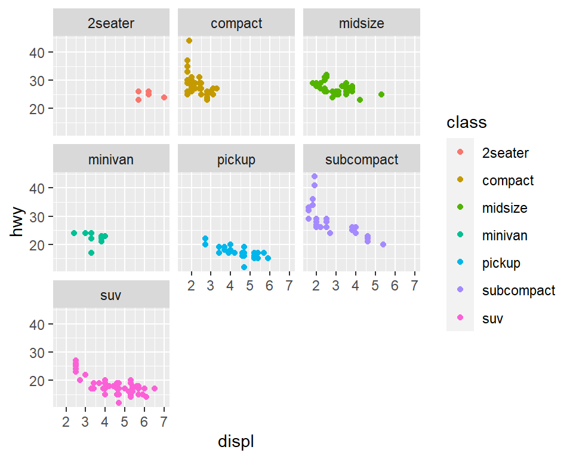

```r
pc +
   geom_point() +
   facet_wrap(vars(class))
```

### 2.4.1 並べ方指定

- 列数： ncol = 数字
- 行数： nrow = 数字

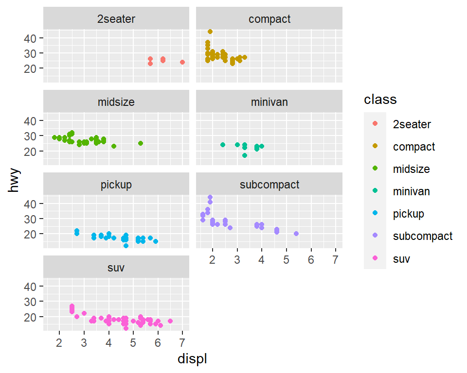

```r
pc +
   geom_point() +
   facet_wrap(vars(class),
             ncol = 2)
```

### 2.4.2 グラフ外にテキストを追加

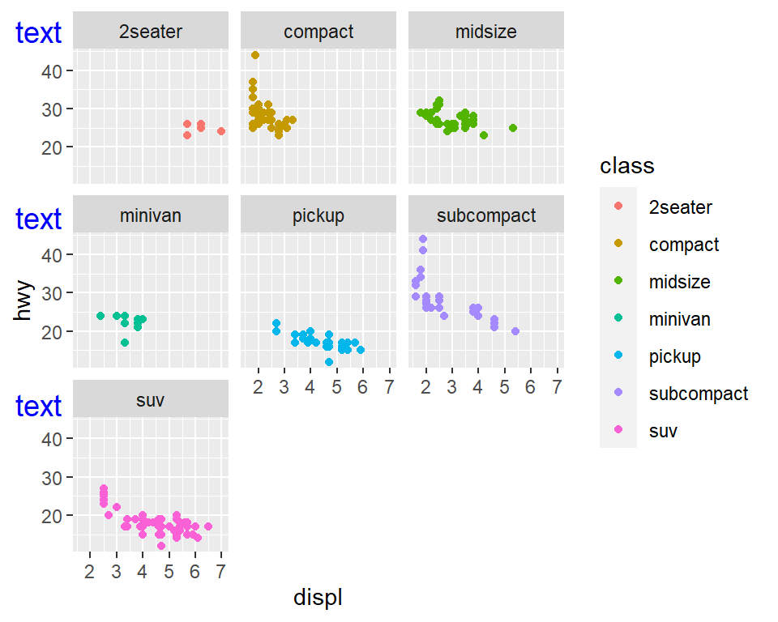

```r
library(cowplot)

pc_wrap <-
pc +
   geom_point() +
   facet_wrap(vars(class))

ggdraw(pc_wrap) +
  draw_label("text", x = 0.05, y = 0.95, color = "blue") +
  draw_label("text", x = 0.05, y = 0.65, color = "blue") +
  draw_label("text", x = 0.05, y = 0.35, color = "blue")
```

## 2.5 変数の水準ごとにプロット(全体のプロットも残す)

- `gghilight`パッケージを使う（ここだけで使うので`gghilight::`をつける）

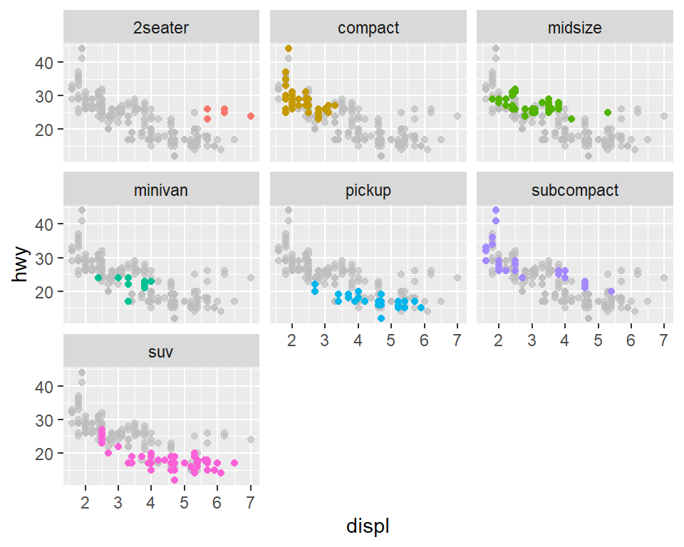

```r
pc +
   geom_point() +
   gghighlight::gghighlight() +
   facet_wrap(vars(class))
```

## 2.6 変数の水準ごとにプロット(2要因)

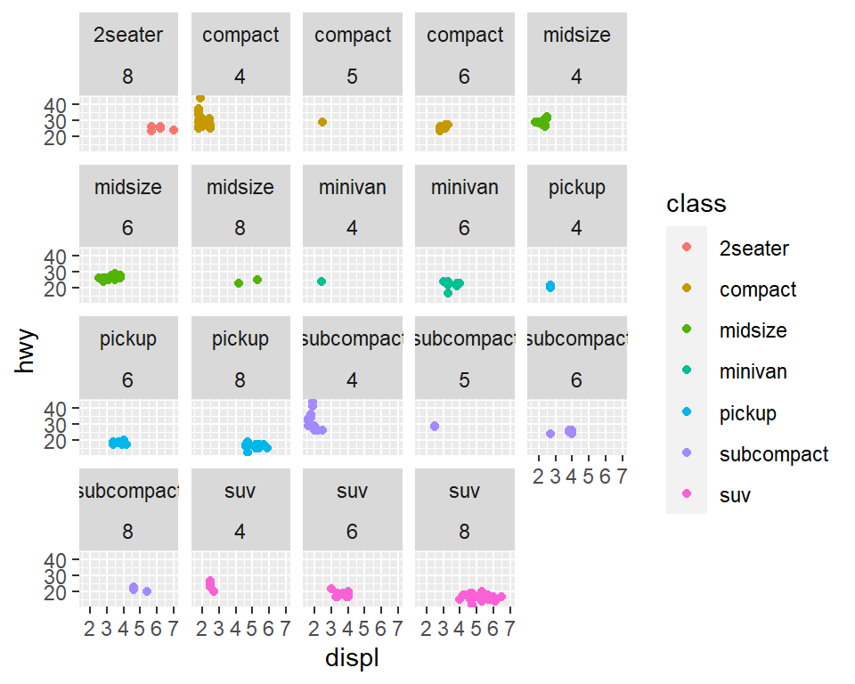

```r
pc +
   geom_point() +
   facet_wrap(vars(class,cyl))
```

### 2.6.1 変数の水準ごとにプロット(2要因):facet_grid()

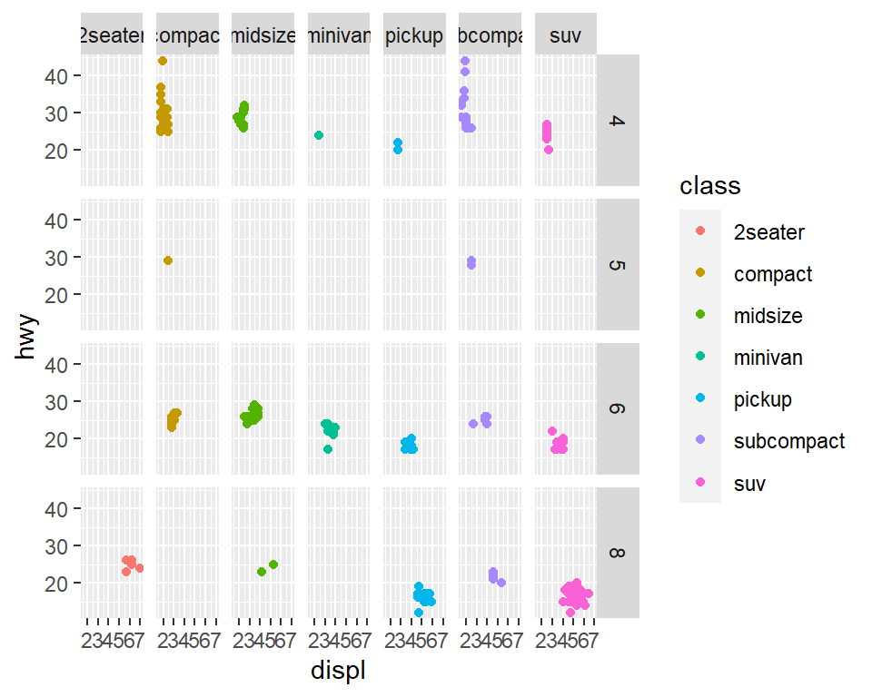

```r
pc +
   geom_point() +
   facet_grid(vars(cyl),vars(class))
```

# 3 折れ線グラフ:geom_line()

## 3.1 ある平均値の年次推移をグループ別にプロットしたい場合

### 3.1.1 必要な形のデータを作成

```r
library(knitr) # kable()を使うため

# 車種(class)と年次別の燃料効率(hwy)平均値データを作成
hwy_class_y <-
mpg %>%
  group_by(class, year) %>%
  summarise(mean_hwy = mean(hwy))

kable(hwy_class_y)
```

| class | year | mean_hwy |
| --- | --- | --- |
| 2seater | 1999 | 24.50000 |
| 2seater | 2008 | 25.00000 |
| compact | 1999 | 27.92000 |
| compact | 2008 | 28.72727 |
| midsize | 1999 | 26.50000 |
| midsize | 2008 | 28.04762 |
| minivan | 1999 | 22.50000 |
| minivan | 2008 | 22.20000 |
| pickup | 1999 | 16.81250 |
| pickup | 2008 | 16.94118 |
| subcompact | 1999 | 29.00000 |
| subcompact | 2008 | 27.12500 |
| suv | 1999 | 17.55172 |
| suv | 2008 | 18.63636 |

#### 3.1.1.1 (参考)wideからlongへのデータ構造変換

##### 3.1.1.1.1 参考のためにwide型作成

```r
hwy_class_y_w <-
  hwy_class_y %>%
  pivot_wider(names_from = year,
              values_from = mean_hwy)

kable(hwy_class_y_w)
```

| class | 1999 | 2008 |
| --- | --- | --- |
| 2seater | 24.50000 | 25.00000 |
| compact | 27.92000 | 28.72727 |
| midsize | 26.50000 | 28.04762 |
| minivan | 22.50000 | 22.20000 |
| pickup | 16.81250 | 16.94118 |
| subcompact | 29.00000 | 27.12500 |
| suv | 17.55172 | 18.63636 |

- このようなデータ（wide型）があったらlong型に変換する

##### 3.1.1.1.2 long型に

```r
hwy_class_y_w %>%
  pivot_longer(-class,            # この変数以外、つまり1999と2008の列を使用
               names_to = "year",
               values_to = "mean_hwy")
```

```
## # A tibble: 14 x 3
## # Groups:   class [7]
##    class      year  mean_hwy
##    <chr>      <chr>    <dbl>
##  1 2seater    1999      24.5
##  2 2seater    2008      25
##  3 compact    1999      27.9
##  4 compact    2008      28.7
##  5 midsize    1999      26.5
##  6 midsize    2008      28.0
##  7 minivan    1999      22.5
##  8 minivan    2008      22.2
##  9 pickup     1999      16.8
## 10 pickup     2008      16.9
## 11 subcompact 1999      29
## 12 subcompact 2008      27.1
## 13 suv        1999      17.6
## 14 suv        2008      18.6
```

### 3.1.2 作図

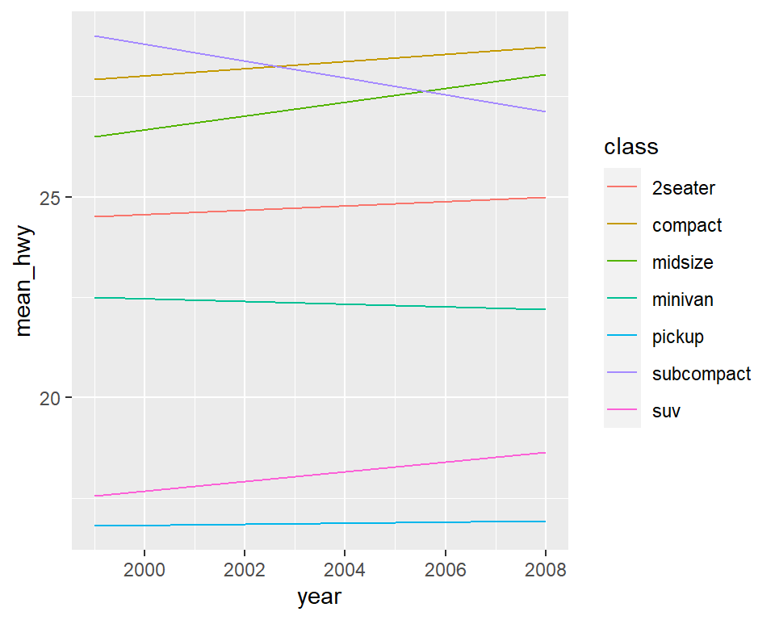

```r
ggplot(hwy_class_y,
       aes(year, mean_hwy, color = class)) +
  geom_line()
```

#### 3.1.2.1 使用した年のみのx軸の表示にしデータ点を追加する

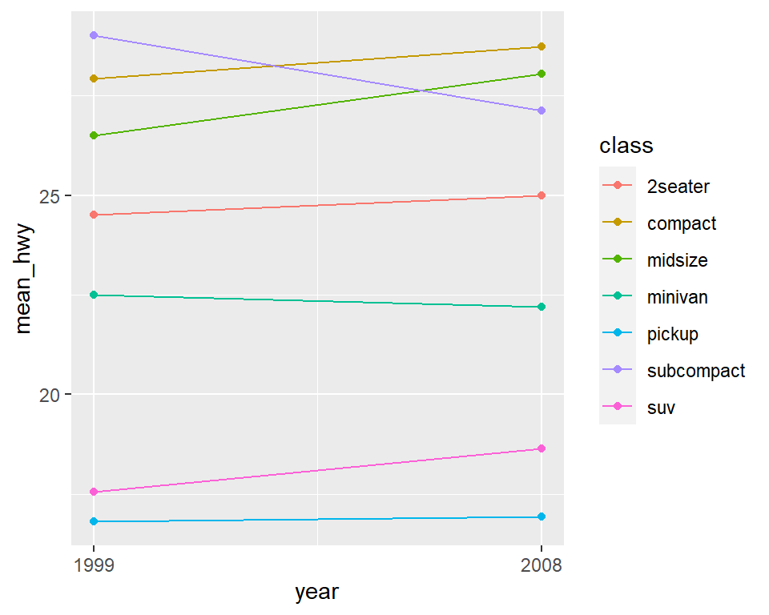

```r
ggplot(hwy_class_y,
       aes(year, mean_hwy, color = class)) +
  geom_point() +
  geom_line() +
  scale_x_continuous(breaks = c(1999, 2008))
```

## 3.2 日付の軸表示

R for Data Science [24 Model building > 24.3 What affects the number of daily flights?](https://bookdown.org/roy_schumacher/r4ds/model-building.html#what-affects-the-number-of-daily-flights) より

### 3.2.1 グラフ用のデータ作成（日別の便数作成と曜日の変数追加）

```r
library(nycflights13) #
library(lubridate)    #

# 日別の便数
daily <- flights %>%
    mutate(date = make_date(year, month, day)) %>%
    group_by(date) %>%
    summarise(n = n())

head(daily)
```

```
## # A tibble: 6 x 2
##   date           n
##   <date>     <int>
## 1 2013-01-01   842
## 2 2013-01-02   943
## 3 2013-01-03   914
## 4 2013-01-04   915
## 5 2013-01-05   720
## 6 2013-01-06   832
```

```r
# 曜日変数追加
daily <- daily %>%
    mutate(wday = wday(date, label = TRUE))
```

#### 3.2.1.1 土曜日のデータに限定

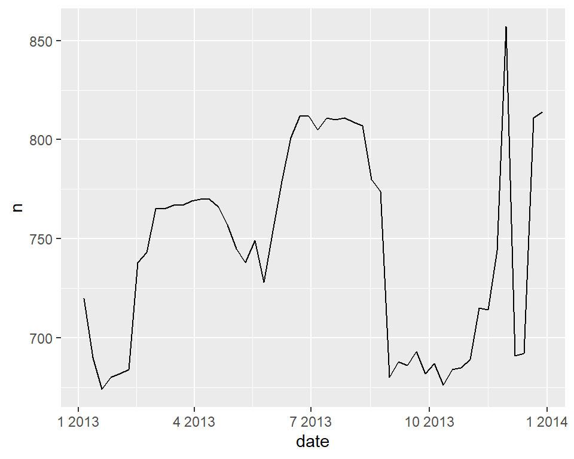

```r
ds <-
daily %>%
    filter(wday == "土") %>%
 ggplot(aes(date, n)) +
    geom_line()

ds
```

### 3.2.2 ラベルの表示調整

- `date_labels =`の後に指定する文字の意味は`?strptime`を参照
- 教科書ggplot2: Elegant Graphics for Data Analysisでは
  - [13 Guides: legends and axes > 13.2.3 Dates: A special case](https://ggplot2-book.org/guides.html#date-scales)

#### 月ごと

- ※ %bで数字のみが出てくる問題については、いずれ検討（おそらくlocaleの問題）

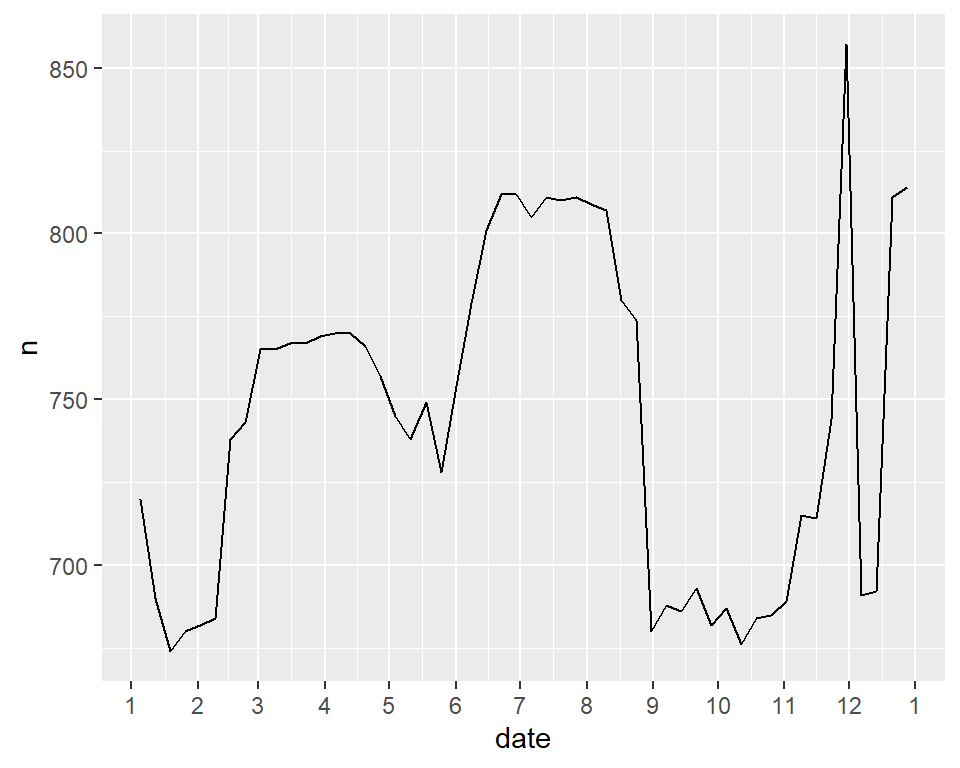

```r
ds +
  scale_x_date(date_breaks = "1 month", date_labels = "%b") # 本来はJanなどの月名の省略文字
```

#### 半年ごと

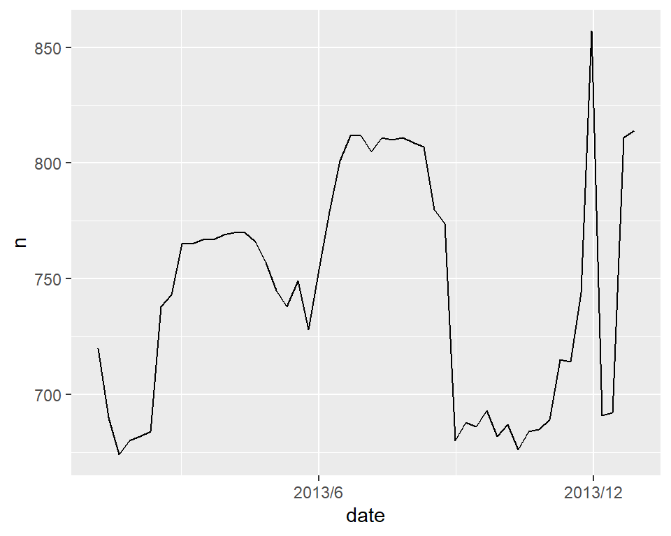

```r
ds +
  scale_x_date(date_breaks = "6 month", date_labels = "%Y/%b") # 西暦/月
```

# 4 棒グラフ(要約値から作る):geom_col()

- 折れ線グラフ:geom_line()の時と同一データを使用
  - 1999年データに限定

```r
# 【再掲】車種(class)と年次別の燃料効率(hwy)平均値データを作成
hwy_class_y <-
mpg %>%
  group_by(class, year) %>%
  summarise(mean_hwy = mean(hwy))
```

## 4.1 デフォルトの図

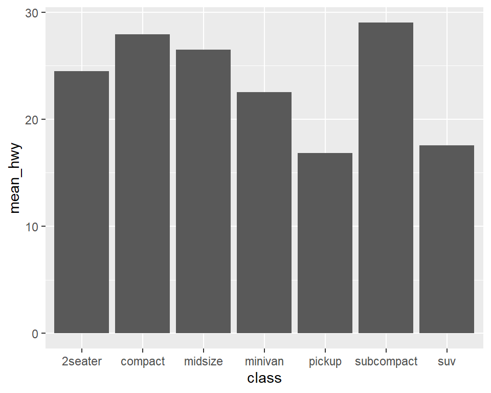

```r
hwy_class_y_99 <-
hwy_class_y %>%
  filter(year == 1999)

pb <-
   ggplot(hwy_class_y_99,
          aes(x = class, y = mean_hwy))

pb  + geom_col()
```

## 4.2 棒の書式

### 4.2.1 色

- 棒グラフの場合、塗りの色は`fill =`で指定

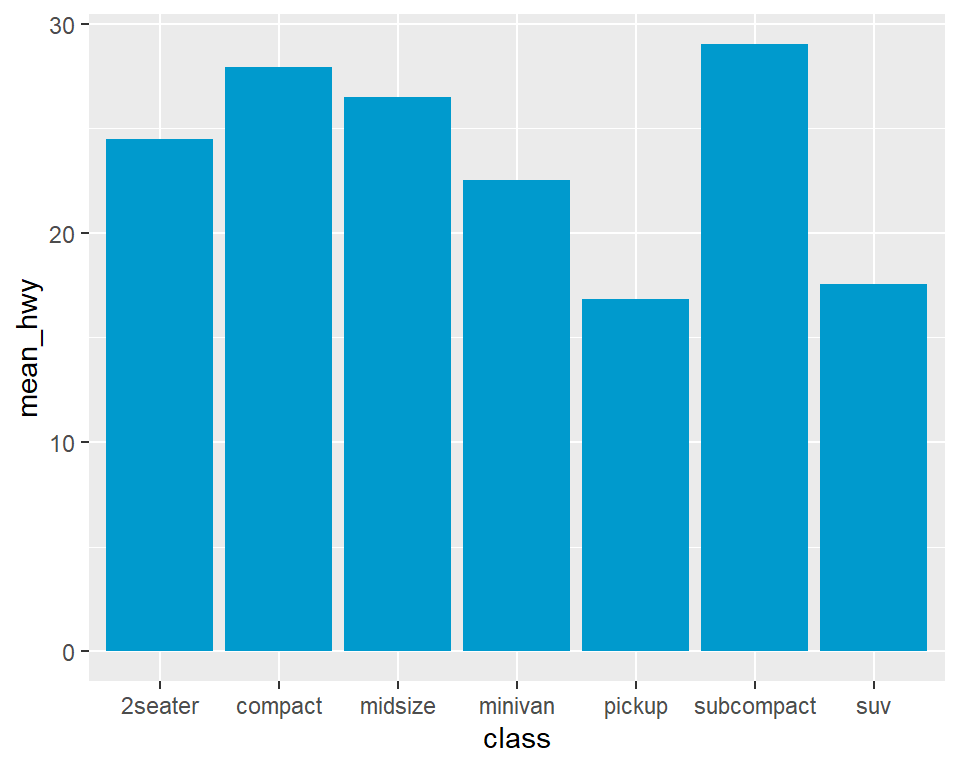

```r
pb  + geom_col(fill = "deepskyblue3")
```

#### 4.2.1.1 棒ごとに色をつける

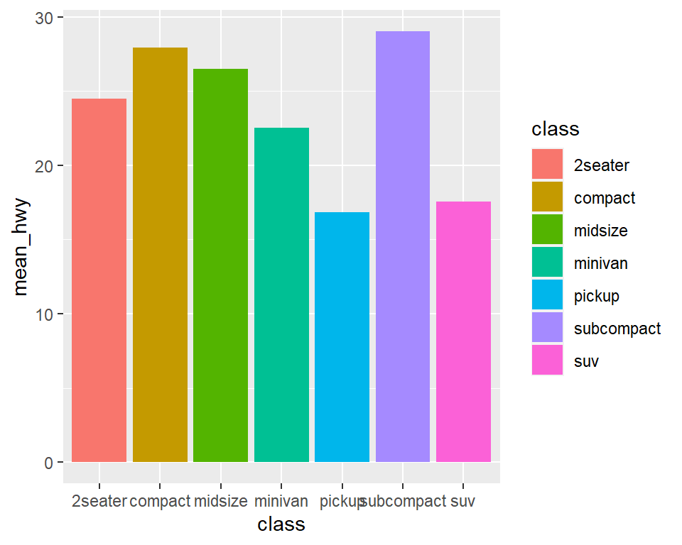

```r
pb  + geom_col(aes(fill = class))
```

#### 4.2.1.2 枠線の色

- `color =`だと枠線の色に

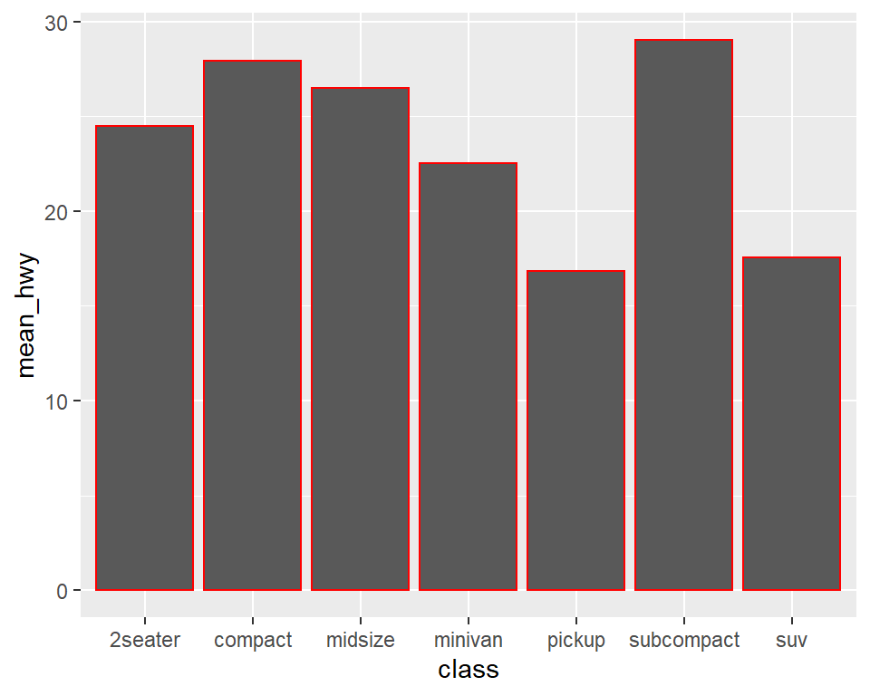

```r
pb  + geom_col(color = "red")
```

### 4.2.2 幅

- デフォルトは0.9

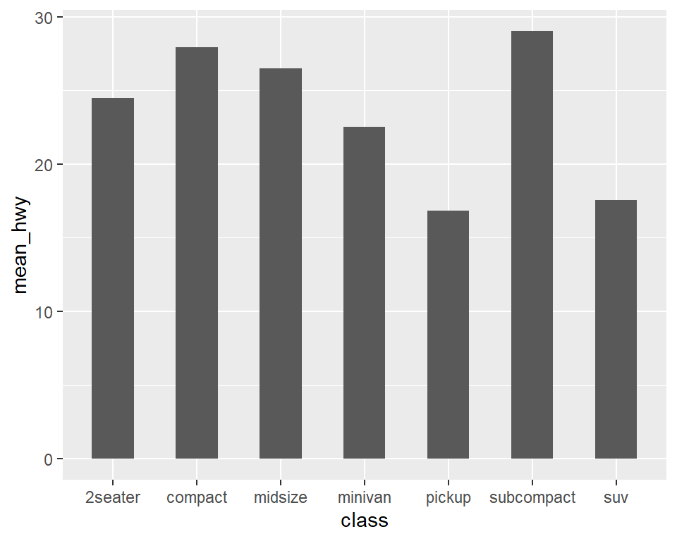

```r
pb  + geom_col(width = 0.5)
```

## 4.3 x軸

### 4.3.1 x軸の順番を任意に

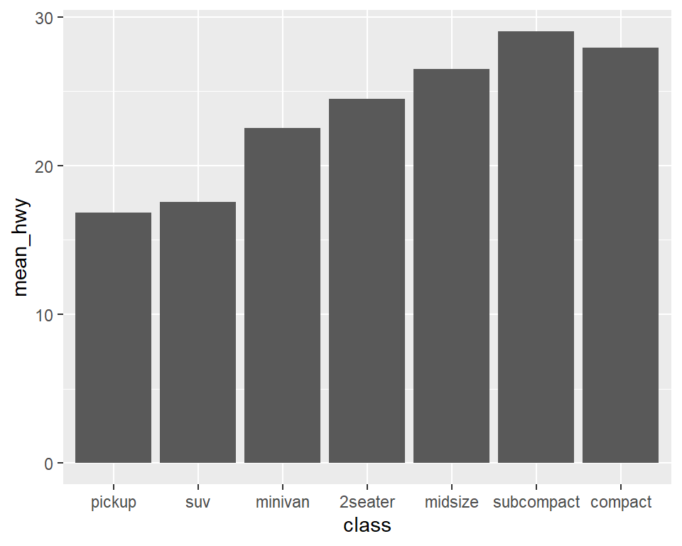

```r
hwy_class_y_99 %>%
  ggplot(aes(
    　　　　　fct_relevel(class,
                         "pickup", "suv", "minivan",
                        "2seater", "midsize", "subcompact", "compact"),
             mean_hwy)) +
  geom_col() +
  labs(x = "class")
```

- 左から降順にしたい場合は、`fct_reorder(class, mean_hwy, .desc = TRUE)`

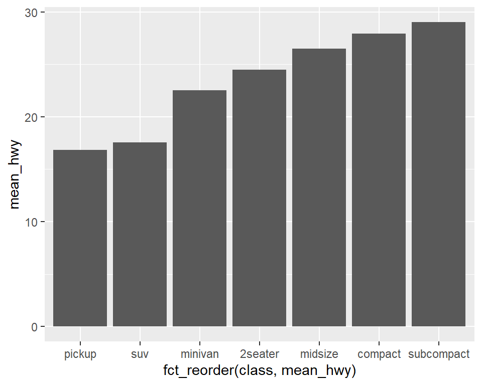

```r
 ggplot(hwy_class_y_99,
          aes(x = fct_reorder(class, mean_hwy),
              y = mean_hwy)) +
  geom_col()
```

### 4.3.3 軸のラベルの向き

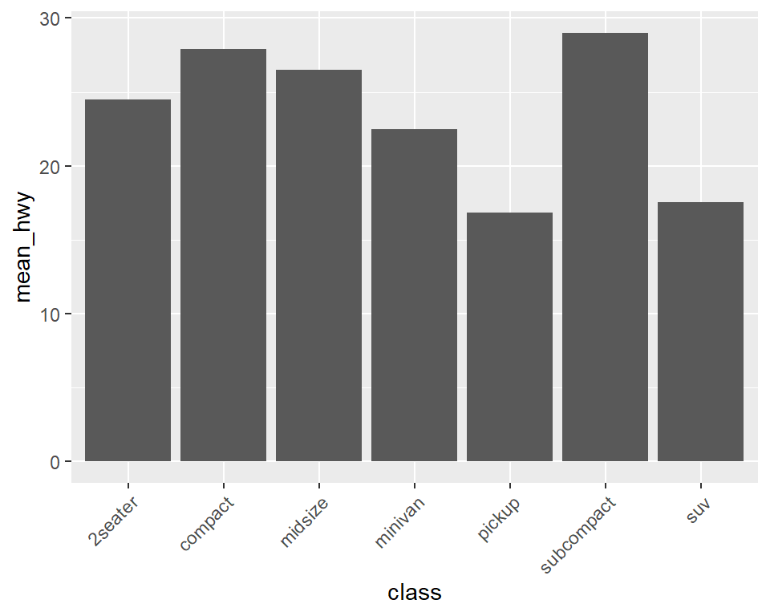

```r
pb  +
  geom_col() +
  theme(axis.text.x = element_text(angle = 45,
                                   hjust = 1))
```

## 4.4 値ラベル

### 4.4.1 値ラベルを表示

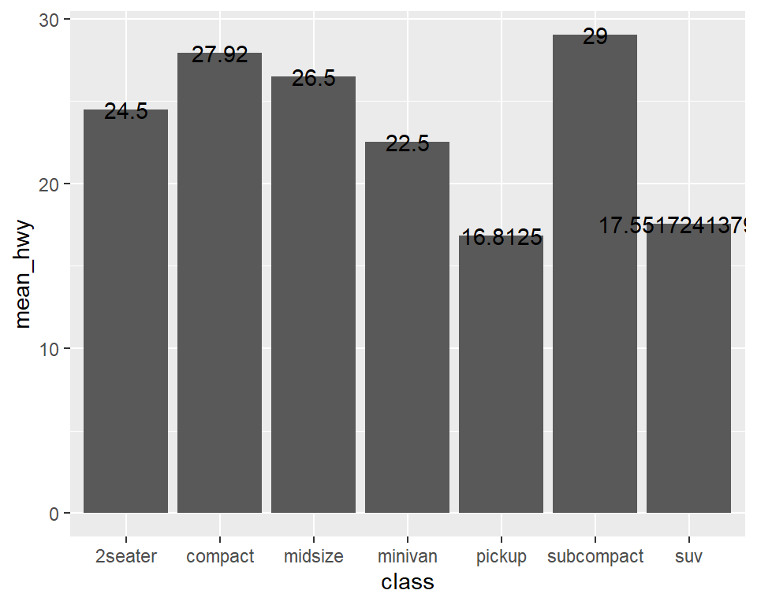

```r
pb +
  geom_col() +
  geom_text(aes(label = mean_hwy))
```

#### 4.4.1.1 値ラベルを表示(見た目を整える)

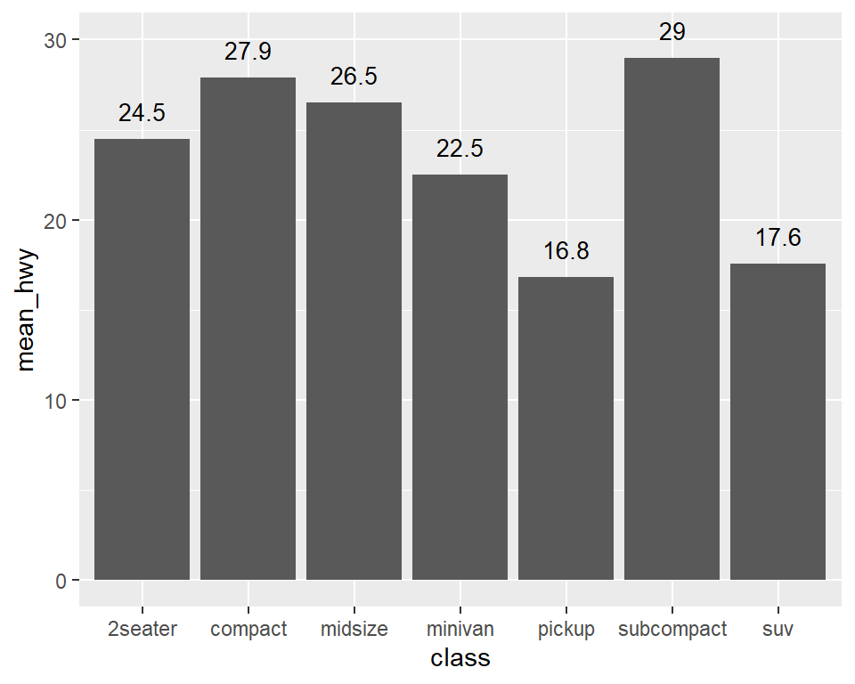

```r
pb +
  geom_col() +
  geom_text(aes(label = round(mean_hwy, 1)), # 値ラベルを丸める
            vjust = -1,                      # 値をグラフの上に表示
            size = 3.5) +                    # 値の文字のサイズ
  scale_y_continuous(limits = c(0, 30))      # y軸の範囲を指定しないとラベルが隠れるため
```

#### 4.4.1.2 値を棒の中に

- `vjust =`の値を大きくするほど下の位置に移動する

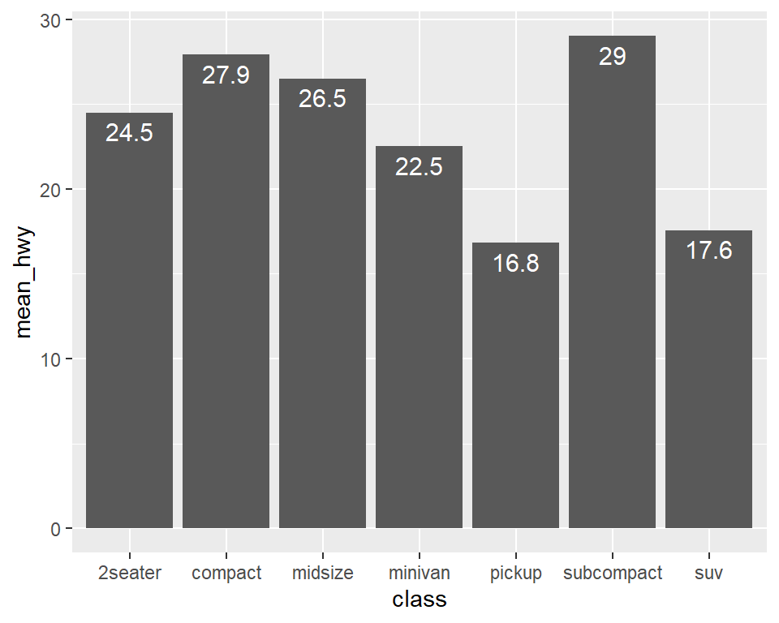

```r
pb +
  geom_col() +
  geom_text(aes(label = round(mean_hwy, 1)), # 値ラベルを丸める
            vjust = 1.5,                     # 値をグラフの中に表示
            size = 4,                        # 文字のサイズ
            color = "white")                 # 文字の色
```